# PySAL is still the fastest topology constructer in the west

One incredibly common question in spatial data analysis is the computation of adjacency relationships. Specifically, given a set of polygons, it's often common to ask queries like:

```
What polygons touch this polygon?
```

Or, in language you might actually know:

```
What neighborhoods surround mine?
```

These questions are usually specified as spatial predicates, and are computed in specialized database software. When answering these questions for statistical analysis, it's often important to have the answer to these queries over all pairs of observations. Thus, for geographic data science, we often require *topology* representing the spatial relationships between our observations. In polygonal data, the graph expressing the topological relationships between the polygons themselves is sometimes called the *line graph* or *dual graph* of the polygonal lattice.

Take, for instance, the common case of feature engineering in geographic data science. Here, we aim to use information about the geography of our data to get "free" data. Using the spatial embedding, we come up with additional information that might be helpful in predicting our outcomes of interest. So, for some data matrix $\mathbf{X}$, we'd like some function $\eta(\mathbf{x}_i)$, that gives a summary of all our features in nearby locations to site $i$. We could compute these averages by repeating many database queries. It's easier, though, to use some *weights* matrix, $\mathbf{W}$, whose product $\mathbf{WX}$ gives a summary of the values around each site. If you're interested in more, check out our [tutorial on geographic spatial data science.](https://www.youtube.com/watch?v=NxGyxwP1Eiw)

PySAL, the python spatial analysis library, has long provided fast methods for computing adjacency relationships from geometric data. This is important, since the computation of pairs of spatial relationships between neighboring pairs of observations can be quite time consuming if special structures are not recognized and exploited.

So, below, I'll show what these weights look like, and provide an example of how PySAL can be nearly an order of magnitude faster than using default `geopandas`, even with a spatial index.

```python
# this only works on the recent PySAL 2.0 release candidate!
from pysal.lib import weights, examples
import geopandas
import matplotlib.pyplot as plt
import numpy as np
%matplotlib inline
%load_ext line_profiler
```

To do this, let's consider a dataset which is (in some senses) quite small: the set of all counties in the US:

```python
counties = geopandas.read_file(examples.get_path('NAT.shp'))
texas = counties.query("STATE_NAME == 'Texas'")
```

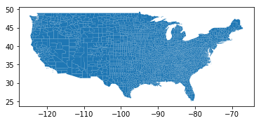

```python
counties.plot()
```

While this is only:

```python
counties.shape[0]
```

```
3085
```

observations, we can find the neighbors for each observation in a simple way using `geopandas`.

### Naive all-pairs-touches

For each geometry, we'll look for other observations that intersect its boundary.

```python
def graph(gdf):
    neighbors = {}
    for i, geometry in enumerate(gdf.geometry):
        observation_ix = gdf.iloc[i].name
        hits = gdf.geometry.touches(geometry)
        these_neighbors = set(hits.index[hits].tolist())
        neighbors[observation_ix] = these_neighbors
    return neighbors
```

```python
%%timeit -n 1
graph(counties)
```

```
1min 13s ± 26.4 s per loop (mean ± std. dev. of 7 runs, 1 loop each)
```

```python
g0 = graph(counties)
```

Breaking down the performance of our algorithm above, the largest and most expensive operation is the `intersects` check. Computationally, it is actually quite hard to check whether or not two polygons' boundaries intersect, especially when there are many vertices on the boundary of the polygon.

### Spatial Indexes

One common strategy uses **spatial indexes** to reduce the number of times the *expensive* computation, point set intersection between two polygons, is executed. To do this, we can use the spatial index to filter out pairs of polygons that are obviously not touching. This lets us evaluate the expensive `intersects` only when our polygons are actually likely to be intersecting.

Thus, the `geodataframe.sindex.intersection` method provides a generator which yields `True` if a geometry's bounding box intersects the target geometry's bounding box and `False` if not. Often, all of the polygons which intersect the target bounding box will end up touching the polygon as well. For example, the first geometry, Lake of the Woods, MN, has three counties that touch its bounding box:

```python
list(counties.sindex.intersection(counties.geometry[0].bounds))
```

```
[40, 30, 22, 0]
```

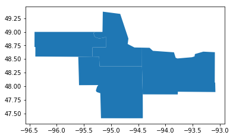

```python
counties.iloc[_].plot()
```

That said, all of those polygons actually touch one another:

```python
counties.geometry.touches(counties.geometry[0]).nonzero()
```

```
(array([22, 30, 40]),)
```

Since bounding box intersection is *necessary* for polygons to touch, this provides a useful filter to reduce the number of expensive polygon `touches` computations required.

But, since this condition is only *necessary*, not *sufficient*, this sometimes is not the case:

```python
for i, geom in enumerate(counties.geometry):
    touches, = counties.geometry.touches(geom).nonzero()
    sindex_hits = list(counties.sindex.intersection(geom.bounds))
    sindex_hits.remove(i)
    if set(touches) != set(sindex_hits):
        countyname, statename = counties.iloc[i][['NAME', 'STATE_NAME']]
        print('found a spatial index miss in {} County, {}!'.format(countyname,
                                                            statename))
        break
```

```
found a spatial index miss in Lincoln County, Montana!
```

For example, in Lincoln County, MT, we see that there are spatial index misses, where bounding box intersection exists, but polygons don't intersect.

Polygons with blue stars in their center are counties whose bounding boxes overlap with our target, Lincoln County (colored light red with a blue `x` in the center). Red-bounded polygons are polygons that *actually* touch.

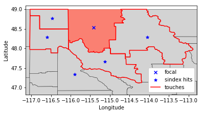

```python
counties.plot(color='lightgrey', edgecolor='k', linewidth=.4)
counties.iloc[[i]].plot(color='salmon', ax=plt.gca())
counties.iloc[[i]].centroid.plot(color='blue', ax=plt.gca(),
                                 marker='x', label='focal')
counties.iloc[sindex_hits].centroid.plot(color='blue', ax=plt.gca(),
                                         marker='*', label='sindex hits')
counties.iloc[touches].boundary.plot(color='red', ax=plt.gca(),
                                     label='touches')
w,e,s,n = counties.iloc[sindex_hits].unary_union.buffer(.1).bounds
plt.axis((w,s,e,n))
plt.legend(loc = 'lower right', framealpha=1)
plt.xlabel("Longitude")
plt.ylabel("Latitude")
plt.show()
```

On average, how efficient our spatial index is depends on the regularity of the geometries in the dataset. Highly irregular non-convex geometries will result in significantly more index misses than those where polygons are regularly spaced and evenly-sized. For US counties, we have a pretty acceptable number of tree hits:

```python
all_sindex_hits = 0
all_touches = 0
for i, geom in enumerate(counties.geometry):
    touches, = counties.geometry.touches(geom).nonzero()
    sindex_hits = list(counties.sindex.intersection(geom.bounds))
    sindex_hits.remove(i)
    all_sindex_hits += len(sindex_hits)
    all_touches += len(touches)
print("{:.2f}% of spatial index intersections are also touching polygons"
      "".format(all_touches/all_sindex_hits * 100))
```

```
92.54% of spatial index intersections are also touching polygons
```

Further, our spatial index is very good at reducing the number of polygons we use for expensive intersection operations. Instead of requiring $N^2$ `touches` computations (or, at best, $N^2/2$ since `touches` is symmetrical), we require less than one percent of the number of `touches` evaluations if we use the spatial index:

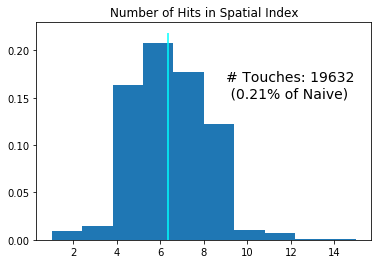

```python
n_hits = [len(list(counties.sindex.intersection(geom.bounds)))-1
         for geom in counties.geometry]
plt.hist(n_hits, normed=True)
plt.vlines(np.mean(n_hits), *plt.gca().get_ylim(), color='cyan')
plt.text(x=9, y=.15, s='# Touches: {} \n ({:.2f}% of Naive)'.format(np.sum(n_hits),
                                                  np.sum(n_hits)/len(counties)**2*100),
         fontsize=14)
plt.title("Number of Hits in Spatial Index")
plt.show()
```

So, how well does this speedup perform?

```python
def graph_sindex(gdf):
    neighbors = {}
    for i, geometry in enumerate(gdf.geometry):
        observation_ix = gdf.iloc[i].name
        hits_sindex = list(gdf.sindex.intersection(geometry.bounds))
        hits = gdf.geometry.iloc[hits_sindex].touches(geometry.boundary)
        these_neighbors = set(hits.index[hits].tolist())
        these_neighbors.remove(observation_ix)
        neighbors[observation_ix] = these_neighbors
    return neighbors
```

```python
%%timeit -n 1
graph_sindex(counties)
```

```
6.96 s ± 273 ms per loop (mean ± std. dev. of 7 runs, 1 loop each)
```

From 1 minute to 6 seconds; that's an excellent improvement! Let's check if they're equal graphs, though:

```python
g1 = graph_sindex(counties)
```

```python
g0 == g1
```

```
True
```

Yep! They are!

### The Cost of GEOS point-set operations

While 6 seconds for a graph from ~3k polygons seems relatively long, I believe it's about as fast as you can get with using pure Python on top of `shapely` objects, without going directly into the GEOS object `shapely` wraps. Part of this is indirection of moving back and forth between the Python and the C (where GEOS is), but part of the concern is *also* that the topological `touches` relationship can be made slightly more simple for most data.

Formally, [two observations touch when they share a boundary point (and no interior points)](https://en.wikipedia.org/wiki/DE-9IM#Spatial_predicates). If the geometries are *planar* (i.e. they exist in one plane with no overlap), the only time two polygons can share a boundary point is when they share a vertex on their boundary. So, it's sufficient to examine the vertexes on the polygon boundary; when at least one point is shared, the polygons `touch`.

Exploiting this planarity realization, `pysal`, the python spatial analysis library, has special fast constructors for these kinds of graphs. They extract the vertices on the boundary of each polygon and checks when polygons share a common boundary vertex.

```python
def graph_pysal(gdf):
    w = weights.Contiguity.Queen.from_dataframe(gdf)
    return w.neighbors
```

```python
%%timeit -n 1
graph_pysal(counties)
```

```
500 ms ± 23.1 ms per loop (mean ± std. dev. of 7 runs, 1 loop each)
```

Whereas our first speedup dropped us quite far (from a minute to 6 seconds for a graph of the counties that tough), this speedup reduces us further still, down to under a second for the adjacency graph of 3k polygons.

Checking if they are equal, we need to ensure that neighbors in the neighbor dictionary are cast to sets:

```python
g2 = graph_pysal(counties)
```

```python
g2 = {k:set(v) for k,v in g2.items()}
```

And with this, we can check equality:

```python
g2 == g1
```

```
True
```

And, we can see what the adjacency graph looks like, too, using PySAL.

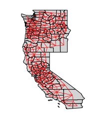

```python
west_is_best = counties.query("STATE_NAME in ('California', 'Oregon', 'Washington')").reset_index()
W = weights.Contiguity.Queen.from_dataframe(west_is_best)
ax = west_is_best.plot(color='lightgrey', edgecolor='k', )
f,ax = W.plot(west_is_best, ax=ax,
              edge_kws=dict(color='r', linewidth=.5),
              node_kws=dict(marker=''))
ax.set_axis_off()
```

# We're undergoing some renovation

but, if you'd like to preview this new version of `pysal`, install the release candidate using:

```
pip install --pre pysal
```